# Mini project

## Notebook made by

| **Name** | **Student id** | **email** |
| --- | --- | --- |
| Wilco van Dijk | 10590307 | wilcodijk@gmail.com |
| Wouter van Velzen | 10617272 | vanvelzenwouter@gmail.com |
| Nynke Heussen | 10634118 | nynkeheussen@hotmail.com |

[figure not shown]

# Cosine similarity: toewijzing op basis van woordfrequentie

Nynke Heussen - Wilco van Dijk - Wouter van Velzen

## Abstract

In deze paper wordt er onderzoek gedaan naar de volgende vraag: in hoeverre kan een proefschrift aan de hand van de woordfrequentie worden toegewezen aan de bijbehorende supervisor met behulp van de cosine similarity? Om deze vraag te kunnen beantwoorden wordt de volgende deelvraag ook onderzocht: in hoeverre kunnen de desbetreffende faculteiten van de verschillende supervisors onderscheiden worden? De proefschriften zijn afkomstig van UvA Dare en door middel van verschillende methodes zijn de belagrijkste woorden over gebleven. Met een zekerheid van 80% is te zeggen dat een proefschrift op basis van de woordfrequentie wordt toegewezen aan de bijbehorende supervisor. Wel is het erg lastig om de faculteit te kunnen onderscheiden van de supervisors.

## Inleiding

Om te kunnen promoveren aan een universiteit moet er een proefschrift geschreven worden waarmee de titel doctor kan worden behaald. Bij dit proces wordt een supervisor gekozen die kennis beschikt over het desbetreffende onderwerp van het proefschrift, om zo de promovendus te ondersteunen. Op de UvA Dare (Digital Academic Repository) site zijn er diverse proefschriften beschikbaar. Voor dit onderzoek zijn de proefschriften van vier supervisors gebruikt: prof. dr. J. F. A. K. van Benthem, prof. dr. M. de Rijke, prof. dr. D. Swaab en prof. dr. J. Grin. Hiervan zijn de eerste drie supervisors verbonden aan de Faculteit der Natuurwetenschappen, Wiskunde en Informatica (FNWI) en de laatste supervisor aan de Faculteit der Maatschappij- en Gedragswetenschappen (FMG)

Voor het onderzoek worden de proefschriften vergeleken op basis van het woordgebruik met de bijbehorende frequentie. Dit om te kijken of er sprake is van similariteit tussen de proefschriften waar een professor supervisor van is geweest. De similariteit wordt bepaald door de cosine similarity uit te rekenen waar een waarde tussen 0 en 1 uitkomt. Een hoge cosine waarde houdt in dat de proefschriften erg gerelateerd aan elkaar zijn. Er wordt gebruik gemaakt van deze similariteit-score omdat dit de beste maat is voor tekstdocumenten (Strehl et al., 2000). Dit omdat de cosine similarity niet afhankelijk is van lengte en zo verschillende documenten dus vergeleken kunnen worden.

\begin{equation} \cos ({\bf t},{\bf e})= {{\bf t} {\bf e} \over \|{\bf t}\| \|{\bf e}\|} = \frac{ \sum_{i=1}^{n}{{\bf t}_i{\bf e}_i} }{ \sqrt{\sum_{i=1}^{n}{({\bf t}_i)^2}} \sqrt{\sum_{i=1}^{n}{({\bf e}_i)^2}} } \end{equation}

In de literatuur wordt met behulp van de cosinus de similariteit tussen tekstdocumenten bepaald, in dit onderzoek gaat het specifiek over proefschriften en wordt aan de hand van de hoogste similariteit het proefschrift ook nog toegewezen aan één van de vooraf gedefiniëerde categorieën (single-label). De volgende vraag staat daarom centraal in het onderzoek van deze paper: in hoeverre kan een proefschrift aan de hand van de woordfrequentie worden toegewezen aan de bijbehorende supervisor met behulp van de cosine similarity? Om de hoofdvraag van deze paper te kunnen beantwoorden, is er een deelvraag opgesteld die als volg luidt: in hoeverre kunnen de desbetreffende faculteiten van de verschillende supervisors onderscheiden worden?

## Gerelateerd werk

[Strehl et al. (2000)](http://www.aaai.org/Papers/Workshops/2000/WS-00-01/WS00-01-011.pdf) tonen aan dat voor tekstdocumenten-similiriteit de cosinus de beste uitkomst geeft en dat de Euclidean-maat het slechts presteert. Twee te vergelijken documenten worden als vectors gepresenteerd waardoor de hoek de maat voor correlatie vormt. Dit is in figuur 1 te zien [(Huang, 2008)](http://www.nzcsrsc08.canterbury.ac.nz/site/proceedings/Individual_Papers/pg049_Similarity_Measures_for_Text_Document_Clustering.pdf), als de vergelijking plaatsvindt tussen meer dan twee documenten dan wordt het figuur uitgebreid in het aantal dimensies.

[figure not shown]

Toewijzen aan vooraf gedefiniëerde categorieën kan gebeuren op basis van single-label of multilabel tekst catagorisatie. Vanuit een theoretisch perspectief is single-label categorisatie algemener dan multilabel categorisatie omdat het algoritme voor single-label ook voor multilabel gebruikt kan worden, andersom is dit niet het geval (Sebastiani, 2002). De meest gebruikte benadering van tekstvisualisatie als word clouds is door middel van de woordfrequenties tellen en de meest gebruikte woorden in een word cloud tonen (Feinberg, 2008). Het is waarschijnlijk dat word clouds overeenkomende woorden bevatten als verschillende frequentie-gebaseerde word clouds voor subsets van een documentencollectie worden vergeleken [(Collins et al., 2009)](http://ieeexplore.ieee.org/stamp/stamp.jsp?tp=&arnumber=5333443).

## Methodologie

### Data vergaring

De data is afkomstig van de website UvA Dare, waar de gepubliceerde artikelen van de UvA staf worden opgeslagen en beschikbaar gemaakt zijn. Om de data van de site te kunnen downloaden, is er gebruik gemaakt van wget. In de opdrachtprompt is met behulp van wget een command opgesteld, waarbij de achternaam van de supervisor is gebruikt voor de zoekterm. Alleen UvA Dare heeft de bestanden zo opgeslagen, dat er geen type bestaan aan verbonden is, maar het waren zijn eigenlijk PDF bestanden.

Er is voor gekozen om alleen de proefschriften te selecteren met een grootte van minimaal 10 MB, omdat kleine proefschriften te weinig zeggen over het woordgebruik. Om de tekst te kunnen inlezen met Python is de PDFminer gebruikt. Deze module zorgt ervoor dat de tekst uit de bestanden wordt omgezet in een string. Zonder het gebruik van deze module zouden er alleen vreemde karakters komen, en kan de tekst niet worden vergeleken.

### Data betekenis

De bestanden zijn diverse proefschriften van promovendi. Deze proefschriften gaan over uiteenlopende thema’s waarbij promovendi onderzoek doen met behulp van een supervisor om zo hun onderzoeksvraag te kunnen beantwoorden. In de proefschriften staan tekst en vaak ook illustraties. Deze illustraties worden in dit onderzoek niet gebruikt en er wordt dus alleen naar de inhoud gekeken

### Methode

Om de woordfrequenties van de proefschriften te kunnen berekenen zijn er verschillende methodes toegepast om tot een werkbare dataset te komen (zie de appendix voor de code). Ten eerste zijn er met behulp van regular expressions de leestekens, bijvoorbeeld ‘!’, ‘.’, en dergelijke uitgefilterd. Hierdoor blijven er alleen woorden over.

Tot slot zijn de woorden gelemattiseerd, wat volgens Korenius et al. (2004) inhoudt dat van elk woord de basisvorm wordt genomen, bijvoorbeeld ‘working’ en ‘works’ worden beide ‘work’. Hierdoor vindt er normalisatie plaats, omdat bijvoorbeeld werkwoorden en zelfstandignaamwoorden niet meer als verschillend worden geclassificeerd en er zodoende een betere vergelijking van de woordfrequenties gemaakt kan worden. Nu kan er van elk woord de woordfrequentie berekend worden bij de proefschriften.

```python
import nltk
import re
from collections import Counter
from pattern.en import  lemma  # also exists for Dutch
import pattern.nl #  import lemma
import pyPdf
from wordcloud import WordCloud
import matplotlib.pyplot as plt
import pickle
import math
%matplotlib inline
```

```python
from pdfminer.pdfinterp import PDFResourceManager, PDFPageInterpreter
from pdfminer.converter import TextConverter
from pdfminer.layout import LAParams
from pdfminer.pdfpage import PDFPage
from cStringIO import StringIO

def convert_pdf_to_txt(path):
    rsrcmgr = PDFResourceManager()
    retstr = StringIO()
    codec = 'utf-8'
    laparams = LAParams()
    device = TextConverter(rsrcmgr, retstr, codec=codec, laparams=laparams)
    fp = file(path, 'rb')
    interpreter = PDFPageInterpreter(rsrcmgr, device)
    password = ""
    maxpages = 0
    caching = True
    pagenos=set()
    for page in PDFPage.get_pages(fp, pagenos, maxpages=maxpages, password=password,caching=caching, check_extractable=True):
        interpreter.process_page(page)
    fp.close()
    device.close()
    str = retstr.getvalue()
    retstr.close()
    return str
```

```python
# Inspect the stopwords
nltk.download("punkt")

en_stopwords= set(nltk.corpus.stopwords.words('english')) # we turn it into a set because of speed
```

```python
def pdf_to_counter(pdf):
    text = convert_pdf_to_txt(pdf)
    TextTokens= nltk.word_tokenize(text.decode('utf-8'))
    # Do it for all
    #  This list is made to filter out all the words that are often used in papers, and therefore not very relevant
    proefschriftwoorden = ['chapter', 'gegeven', 'niet','procedure', 'onderzoek', 'part', 'article', 'method', 'also', 'case', 'university', 'study', 'experiment', 'score', 'author', 'show', 'compare', 'copyright',
                          'section', 'value', 'find', 'research', 'compare', 'literature', 'state', 'term', 'used', 'feature', 'number', 'abstract', 'form', 'table', 'example',
                          'purpose', 'conclusion', 'wordt','factor', 'review', 'result', 'theory', 'model', 'function', 'variable', 'report', 'data', 'however']

    #This is where the filtering takes place
    #Everything is lemmatized that is not in any of the regular expression searches or matches.
    # This to filter out all the words that contain or start with a weird symbol.
    # After that all words are filtered out that are shorter than  4 symbols
    # And all the words are filtered out that are not in proefschriftwoorden or the english stopwords
    NormalizedTextTokens= [lemma(s.lower()) for s in TextTokens
                             if not re.match(r'^\W+$|\d',s) and
                                not re.search(r'\W', s) and
                                len(s) >3 and
                                not s in en_stopwords
                                and not lemma(s.lower()) in proefschriftwoorden]

    # Do some repairs
    # try re.sub(u'\ufb01','fi', u'de\ufb01nition')
    # with lemmatization we get new 3 letter words
    NormalizedTextTokens=[re.sub(u'\ufb01','fi',w) for w in NormalizedTextTokens if len(w) >3 ]
    WordCount= Counter(NormalizedTextTokens)
    return WordCount
```

Om de hoofdvraag te kunnen beantwoorden, wordt de woordfrequentie van het totaal aantal proefschriften van elke supervisor berekend (zie appendix voor de werking van de code). Vervolgens kan er dan steeds de woordfrequentie van 1 artikel uit de databestanden worden vergeleken met de totale woordfrequentie van elke supervisor. Deze vergelijking wordt gedaan met behulp van de cosine similarity, waarbij de score tussen de 0 en 1 kan liggen. Hoe hoger deze score, hoe meer gelijkenis er is tussen de woordfrequentie van het losse proefschrift ten aanzien van de totale woordfrequentie van alle promovendi van een supervisor.

Er worden dan vier scores berekend, aangezien er vier supervisors zijn waar het artikel toe kan behoren. Het proefschrift wordt gelabeld met de supervisor met de hoogste cosine similarity score. De toewijzing is fout op het moment dat de supervisor niet overeenkomt met de daadwerkelijke supervisor van het proefschrift en is dus goed als het wel de daadwerkelijke supervisor is.

```python
#Here the cosine similarity between two counter functions is calculated
def counter_cosine_similarity(c1, c2):
    terms = set(c1).union(c2)
    dotprod = sum(c1.get(k, 0) * c2.get(k, 0) for k in terms)
    magA = math.sqrt(sum(c1.get(k, 0)**2 for k in terms))
    magB = math.sqrt(sum(c2.get(k, 0)**2 for k in terms))
    return dotprod / (magA * magB)
```

```python
def compare(pdf):
    wordCounter = pdf_to_counter(pdf)
    # All the counters of the whole corpuses where saved to stop us from having to calculate them everytime,
    # just like google would do this from web pages
    with open("wordcloudrijke.pickle", 'rb') as f:
        wordcloudrijke = pickle.load(f)

    with open("wordcloudswaab.pickle", 'rb') as f:
        wordcloudswaab = pickle.load(f)

    with open("benthem.pickle", 'rb') as f:
        wordcloudbenthem = pickle.load(f)

    with open("wordcloudgrin.pickle", 'rb') as f:
        wordcloudgrin = pickle.load(f)


    # Here the different cosine similarities are computed between the input and the corpuses of the supervisors
    print "Grin:", counter_cosine_similarity(wordcloudgrin, wordCounter)
    print "Rijke:", counter_cosine_similarity(wordcloudrijke, wordCounter)
    print "Swaab:", counter_cosine_similarity(wordcloudswaab, wordCounter)
    print "Benthem:", counter_cosine_similarity(wordcloudbenthem, wordCounter)

    #Creating the wordcloud
    frequencies = list(wordCounter.most_common(50))
    cloud = WordCloud().generate_from_frequencies(frequencies)
    plt.axes([0.8, 1, 1.5, 1.5])
    plt.imshow(cloud, aspect = "auto")
    plt.axis("off")
```

```python
# Here the different wordfrequency lists are compared to each other with the cosine similarity, this to show that de Rijke and van
# Benthem have a pretty high similarity score

with open("wordcloudgrin.pickle", 'rb') as f:
    wordcloudgrin = pickle.load(f)

with open("wordcloudrijke.pickle", 'rb') as f:
    wordcloudrijke = pickle.load(f)

with open("wordcloudswaab.pickle", 'rb') as f:
    wordcloudswaab = pickle.load(f)

with open("benthem.pickle", 'rb') as f:
    wordcloudbenthem = pickle.load(f)

print "Rijke - Grin:", counter_cosine_similarity(wordcloudrijke, wordcloudgrin)
print "Swaab - Grin:", counter_cosine_similarity(wordcloudswaab, wordcloudgrin)
print "Benthem - Grin:", counter_cosine_similarity(wordcloudbenthem, wordcloudgrin)
print "Rijke - Swaab:", counter_cosine_similarity(wordcloudswaab, wordcloudrijke)
print "Benthem - Swaab:", counter_cosine_similarity(wordcloudbenthem, wordcloudswaab)
print "Benthem - Rijke:", counter_cosine_similarity(wordcloudbenthem, wordcloudrijke)
```

```
Rijke - Grin: 0.347951533231
Swaab - Grin: 0.396082073753
Benthem - Grin: 0.38665451035
Rijke - Swaab: 0.3415724128
Benthem - Swaab: 0.400223881036
Benthem - Rijke: 0.752252068409
```

Dit proces wordt herhaald bij elk proefschrift van de databestanden, zodoende wordt elk proefschrift gelabeld met een toegewezen supervisor. Er wordt bij dit onderzoek gebruik gemaakt van precision om zo te berekenen hoeveel proefschriften daadwerkelijk juist zijn gelabeld aan één van de vooraf gedefiniëerde categorieën.

```python
import os
from os.path import join, getsize

#make an empty list do dump all the filenames
list_files = []
# Get all the files in the specified folders
for i in ["Swaab/", "de Rijke/", "van Benthem/", "Grin/"]:
    for root, dirs, files in os.walk(i):
        for name in files:
            if root == i:
                file_name = i + str(name)
                list_files.append(file_name)

# Load in the Counter's of the corpuses of the supervisors
with open("wordcloudrijke.pickle", 'rb') as f:
    wordcloudrijke = pickle.load(f)

with open("wordcloudswaab.pickle", 'rb') as f:
    wordcloudswaab = pickle.load(f)

with open("benthem.pickle", 'rb') as f:
    wordcloudbenthem = pickle.load(f)

with open("wordcloudgrin.pickle", 'rb') as f:
    wordcloudgrin = pickle.load(f)

#Make a list to save the estimates
estimate_list = []

# For every file in the previously specified folders
for i in list_files:

    #Create a counter for every pdf
    pdf_i = pdf_to_counter(i)

    #Get all the similarities and save them in a dictionary
    similarities = {"van Benthem": counter_cosine_similarity(wordcloudbenthem, pdf_i),
                    "de Rijke": counter_cosine_similarity(wordcloudrijke, pdf_i),
                    "Swaab": counter_cosine_similarity(wordcloudswaab, pdf_i),
                    "Grin": counter_cosine_similarity(wordcloudgrin, pdf_i)}

    #Get the maximum similarity score
    estimate = max(similarities, key=similarities.get)

    #Get the name of hte folder they were in(the supervisor) and the estimate the program made
    estimate_list.append([i.split('/')[0], estimate])

#Make some empty lists for all the different supervisors
relevant = 0
rijkeList = []
benthemList =[]
grinList = []
swaabList = []

#Calculate the precision and add the estimates + real answers to the different lists
for i in estimate_list:
    if i[0]== i[1]:
        relevant +=1

    if i[0]=="de Rijke":
        rijkeList.append(i)
    elif i[0]=="van Benthem":
        benthemList.append(i)
    elif i[0]=="Grin":
        grinList.append(i)
    elif i[0]=="Swaab":
        swaabList.append(i)
print "Average precision is:", float(relevant)/len(estimate_list)
```

```
Average precision is: 0.828571428571
```

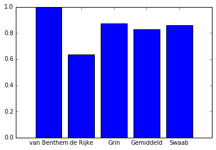

```python
Precisions = {}
Precisions["Gemiddeld"]=0.828571428571

relevant = 0
for i in rijkeList:
    if i[0] == i[1]:
        relevant +=1

Precisions["de Rijke"] = float(relevant)/len(rijkeList)

relevant = 0
for i in grinList:
    if i[0] == i[1]:
        relevant +=1

Precisions["Grin"] = float(relevant)/len(grinList)

relevant = 0
for i in swaabList:
    if i[0] == i[1]:
        relevant +=1

Precisions["Swaab"] = float(relevant)/len(swaabList)

relevant = 0
for i in benthemList:
    if i[0] == i[1]:
        relevant +=1

Precisions["van Benthem"] = float(relevant)/len(benthemList)

plt.bar(range(len(Precisions)), Precisions.values(), align='center')
plt.xticks(range(len(Precisions)), Precisions.keys())

plt.show()
```

## Evaluatie

De hoofdvraag is: in hoeverre kan een proefschrift aan de hand van de woordfrequentie worden toegewezen aan de bijbehorende supervisor met behulp van de cosine similarity?

Zoals hierboven te zien is is de gemiddelde precisie 0.83. In 83 % van de gevallen wijst hij hem dus juist aan. Aan de andere kant, we zijn genoodzaakt om artikelen te nemen die ook al in het corpus zitten. Dit zorgt er dus voor dat het automatisch al sneller aan dat corpus wordt geplakt.

Toch konden deze proefschriften met redelijke nauwkeurigheid worden vastgesteld.

De deelvraag is: in hoeverre kunnen de desbetreffende faculteiten van de verschillende supervisors onderscheiden worden?

Zoals al eerder gezegd is het lastig om supervisors van dezelfde faculteit van elkaar te onderscheiden. Aangezien van Benthem en de Rijke allebei van de FNWI-faculteit zijn, is dit dus zeker een verklaring van de fouten.

## Appendix

```python
# -r recursief. -np "no-parents" (ga alleen naar beneden met ophalen, niet naar boven). -q geef geen output
#!wget -r -np -q  "http://dare.uva.nl/search?field1=promotoren+copromotoren&value1=swaab&join=and&field2=authors+editors&value2=+&smode=advanced&publicatiejaar-min=&publicatiejaar-max=&documenttype=&documenttype-join=or"
```

```python
#pickles aanmaken
#with open("wordcloudkuijper.pickle", 'wb') as f:
    #pickle.dump(WordCount, f)
```

```
Grin: 0.204093321026
Rijke: 0.165888419488
Swaab: 0.41740379918
Benthem: 0.195192024753
```

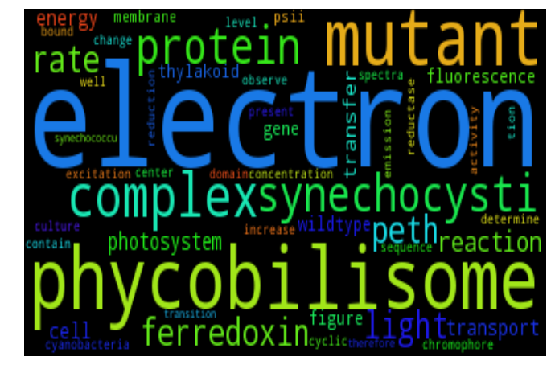

```python
compare("Swaab/8039")
```

```
Grin: 0.210629616658
Rijke: 0.619534648796
Swaab: 0.217934031091
Benthem: 0.376298225667
```

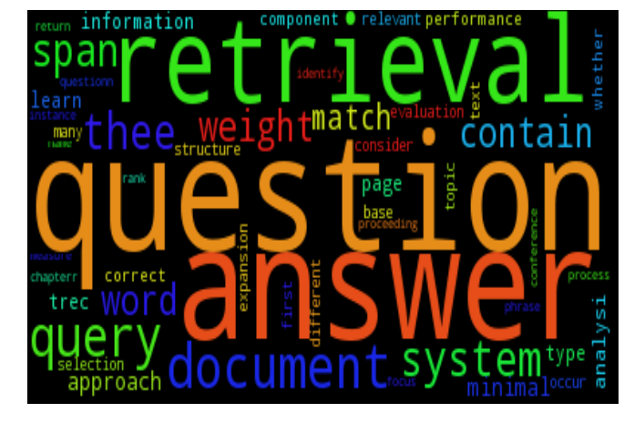

```python
compare("de Rijke/48910")
```

```
Grin: 0.201617886972
Rijke: 0.273672916572
Swaab: 0.225027003393
Benthem: 0.413162818016
```

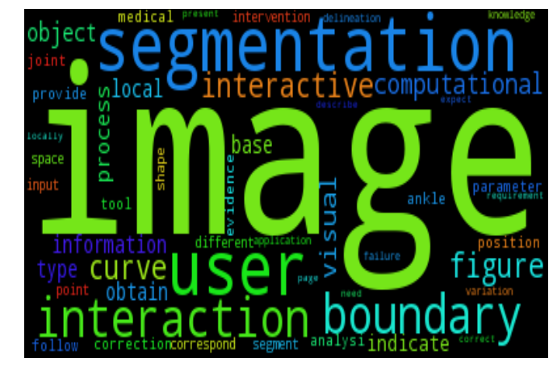

```python
compare("van Benthem/8483")
```

```
(-0.5, 399.5, 199.5, -0.5)
```

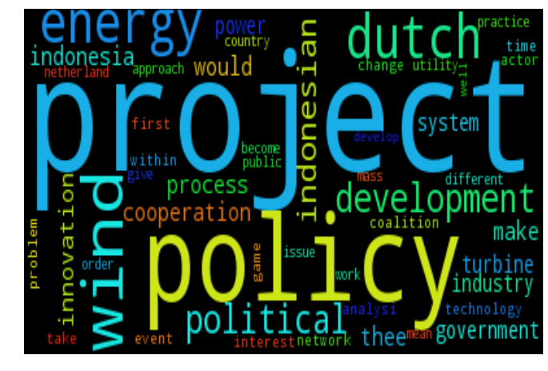

```python
#deelvraag
with open("wordcloudgrin.pickle", 'rb') as f:
    wordCounter = pickle.load(f)
frequencies = list(wordCounter.most_common(50))
cloud = WordCloud().generate_from_frequencies(frequencies)
plt.axes([0.8, 1, 1.5, 1.5])
plt.imshow(cloud, aspect = "auto")
plt.axis("off")
```

```
(-0.5, 399.5, 199.5, -0.5)
```

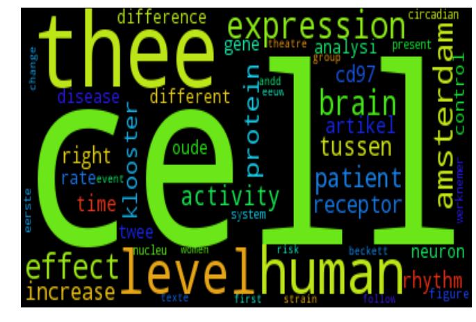

```python
with open("wordcloudswaab.pickle", 'rb') as f:
    wordCounter = pickle.load(f)
frequencies = list(wordCounter.most_common(50))
cloud = WordCloud().generate_from_frequencies(frequencies)
plt.axes([0.8, 1, 1.5, 1.5])
plt.imshow(cloud, aspect = "auto")
plt.axis("off")
```

```
(-0.5, 399.5, 199.5, -0.5)
```

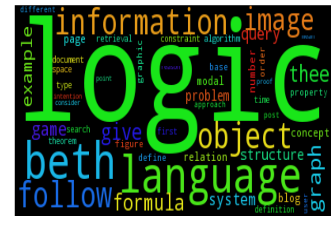

```python
with open("benthem.pickle", 'rb') as f:
    wordCounter = pickle.load(f)
frequencies = list(wordCounter.most_common(50))
cloud = WordCloud().generate_from_frequencies(frequencies)
plt.axes([0.8, 1, 1.5, 1.5])
plt.imshow(cloud, aspect = "auto")
plt.axis("off")
```

```
(-0.5, 399.5, 199.5, -0.5)
```

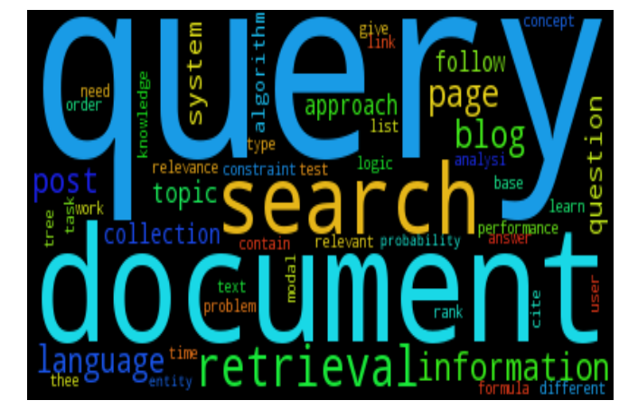

```python
with open("wordcloudrijke.pickle", 'rb') as f:
    wordCounter = pickle.load(f)
frequencies = list(wordCounter.most_common(50))
cloud = WordCloud().generate_from_frequencies(frequencies)
plt.axes([0.8, 1, 1.5, 1.5])
plt.imshow(cloud, aspect = "auto")
plt.axis("off")
```

## Literatuur

Collins, C., Viegas, F. B., & Wattenberg, M. (2009, October). Parallel tag clouds to explore and analyze faceted text corpora. In Visual Analytics Science and Technology, 2009. VAST 2009. IEEE Symposium on (pp. 91-98). IEEE.

Feinberg, J. (2008). Wordle: Beautiful word clouds.

Huang, A. (2008, April). Similarity measures for text document clustering. InProceedings of the sixth new zealand computer science research student conference (NZCSRSC2008), Christchurch, New Zealand (pp. 49-56).

Korenius, T., Laurikkala, J., Järvelin, K., & Juhola, M. (2004, November). Stemming and lemmatization in the clustering of finnish text documents. InProceedings of the thirteenth ACM international conference on Information and knowledge management (pp. 625-633). ACM.

Sebastiani, F. (2002). Machine learning in automated text categorization. ACM computing surveys (CSUR), 34(1), 1-47.

Strehl, A., Ghosh, J., & Mooney, R. (2000, July). Impact of similarity measures on web-page clustering. In Workshop on Artificial Intelligence for Web Search (AAAI 2000) (pp. 58-64).

```python
!ipython nbconvert 10590307_10617272_10634118_miniproject.ipynb  --to slides --reveal-prefix "http://maartenmarx.nl/reveal.js"
```

```
^C
```